# Part09

# 09. 데이터 분석 프로젝트

## ‘한국인의 삶을 파악하라!’

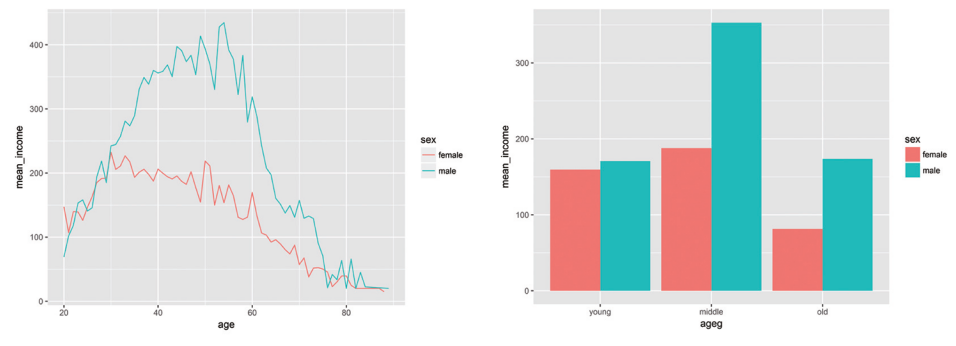

## 09-1. ‘한국복지패널데이터’ 분석 준비하기

#### 한국복지패널데이터

- 한국보건사회연구원 발간
- 가구의 경제활동을 연구해 정책 지원에 반영할 목적
- 2006~2015년까지 전국에서 7000여 가구를 선정해 매년 추적 조사
- 경제활동, 생활실태, 복지욕구 등 수천 개 변수에 대한 정보로 구성

### 데이터 분석 준비하기

#### 패키지 준비하기

```r
install.packages("foreign")  # foreign 패키지 설치
library(foreign)             # SPSS 파일 로드
library(dplyr)               # 전처리
library(ggplot2)             # 시각화
library(readxl)              # 엑셀 파일 불러오기
```

#### 데이터 준비하기

```r
# 데이터 불러오기
raw_welfare <- read.spss(file="data/Koweps_hpc10_2015_beta1.sav", to.data.frame=T)
```

```
data/Koweps_hpc10_2015_beta1.sav: Compression bias (0) is not the usual value of 100
```

```r
# 복사본 만들기
welfare <- raw_welfare
```

#### 데이터 검토하기

```r
head(welfare)
tail(welfare)
View(welfare)
dim(welfare)
str(welfare)
summary(welfare)
```

- 대규모 데이터는 변수가 많고 변수명이 코드로 되어 있어서 전체 데이터 구조를 한눈에 파악하기 어려움
- 변수명을 쉬운 단어로 바꾼 후 분석에 사용할 변수들 각각 파악해야 함

#### 변수명 바꾸기

```r
welfare <- rename(welfare,
                  sex = h10_g3,            # 성별
                  birth = h10_g4,          # 태어난 연도
                  marriage = h10_g10,      # 혼인 상태
                  religion = h10_g11,      # 종교
                  income = p1002_8aq1,     # 월급
                  code_job = h10_eco9,     # 직종 코드
                  code_region = h10_reg7)  # 지역 코드
```

#### 데이터 분석 절차

- 1단계. 변수 검토 및 전처리
- 2단계. 변수 간 관계 분석

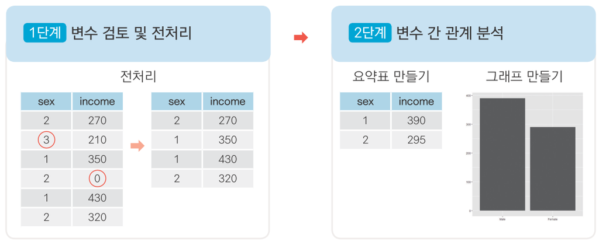

## 09-2. 성별에 따른 월급 차이

## - “성별에 따라 월급이 다를까?”

#### 분석 절차

**1. 변수 검토 및 전처리**

- 성별
- 월급

**2. 변수 간 관계 분석**

- 성별 월급 평균표 만들기
- 그래프 만들기

### 성별 변수 검토 및 전처리

#### 1. 변수 검토하기

```r
class(welfare$sex)
```

```
[1] "numeric"
```

```r
table(welfare$sex)
```

```
   1    2
7578 9086
```

#### 2. 전처리

```r
# 이상치 확인
table(welfare$sex)
```

```
   1    2
7578 9086
```

```r
# 이상치 결측 처리
welfare$sex <- ifelse(welfare$sex == 9, NA, welfare$sex)
# 결측치 확인
table(is.na(welfare$sex))
```

```
FALSE
16664
```

```r
# 성별 항목 이름 부여
welfare$sex <- ifelse(welfare$sex == 1, "male", "female")
table(welfare$sex)
```

```
female   male
  9086   7578
```

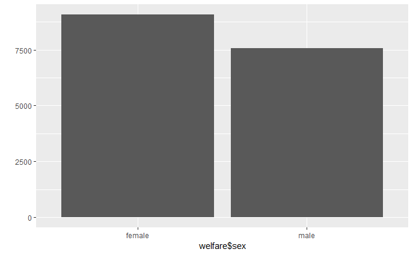

```r
qplot(welfare$sex)
```

### 월급 변수 검토 및 전처리

#### 1. 변수 검토하기

```r
class(welfare$income)
```

```
[1] "numeric"
```

```r
summary(welfare$income)
```

```
   Min. 1st Qu.  Median    Mean 3rd Qu.    Max.    NA's
    0.0   122.0   192.5   241.6   316.6  2400.0   12030
```

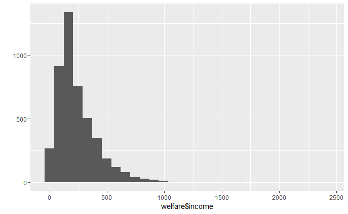

```r
qplot(welfare$income)
```

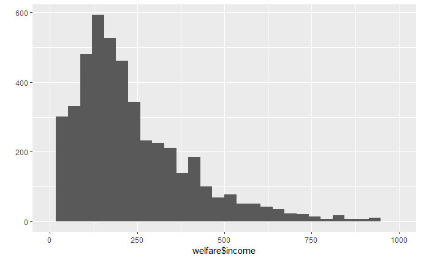

```r
qplot(welfare$income) + xlim(0, 1000)
```

#### 2. 전처리

```r
# 이상치 확인
summary(welfare$income)
```

```
   Min. 1st Qu.  Median    Mean 3rd Qu.    Max.    NA's
    0.0   122.0   192.5   241.6   316.6  2400.0   12030
```

```r
# 이상치 결측 처리
welfare$income <- ifelse(welfare$income %in% c(0, 9999), NA, welfare$income)
# 결측치 확인
table(is.na(welfare$income))
```

```
FALSE  TRUE
 4620 12044
```

### 성별에 따른 월급 차이 분석하기

#### 1. 성별 월급 평균표 만들기

```r
sex_income <- welfare %>%
  filter(!is.na(income)) %>%
  group_by(sex) %>%
  summarise(mean_income = mean(income))
sex_income
```

| sex | mean_income |
| --- | --- |
| female | 163.2471 |
| male | 312.2932 |

#### 2. 그래프 만들기

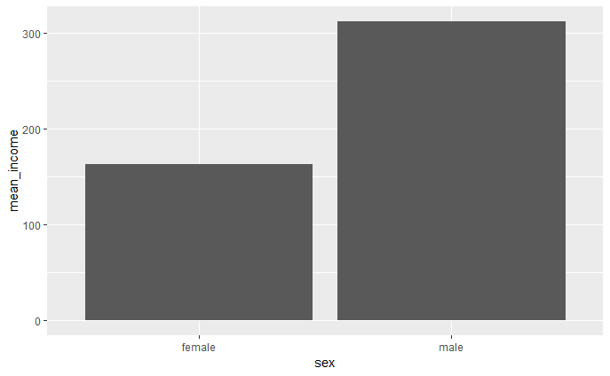

```r
ggplot(data = sex_income, aes(x = sex, y = mean_income)) + geom_col()
```

## 09-3. 나이와 월급의 관계

## - “몇 살 때 월급을 가장 많이 받을까?”

#### 분석 절차

**1. 변수 검토 및 전처리**

- 나이
- 월급

**2. 변수 간 관계 분석**

- 나이에 따른 월급 평균표 만들기
- 그래프 만들기

#### 1. 변수 검토하기

```r
class(welfare$birth)
```

```
[1] "numeric"
```

```r
summary(welfare$birth)
```

```
   Min. 1st Qu.  Median    Mean 3rd Qu.    Max.
   1907    1946    1966    1968    1988    2014
```

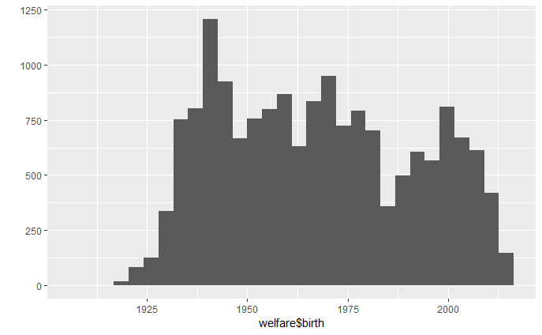

```r
qplot(welfare$birth)
```

#### 2. 전처리

```r
# 이상치 확인
summary(welfare$birth)
```

```
   Min. 1st Qu.  Median    Mean 3rd Qu.    Max.
   1907    1946    1966    1968    1988    2014
```

```r
# 결측치 확인
table(is.na(welfare$birth))
```

```
FALSE
16664
```

```r
# 이상치 결측 처리
welfare$birth <- ifelse(welfare$birth == 9999, NA, welfare$birth)
table(is.na(welfare$birth))
```

```
FALSE
16664
```

#### 3. 파생변수 만들기 - 나이

```r
welfare$age <- 2019 - welfare$birth + 1
summary(welfare$age)
```

```
   Min. 1st Qu.  Median    Mean 3rd Qu.    Max.
   6.00   32.00   54.00   52.43   74.00  113.00
```

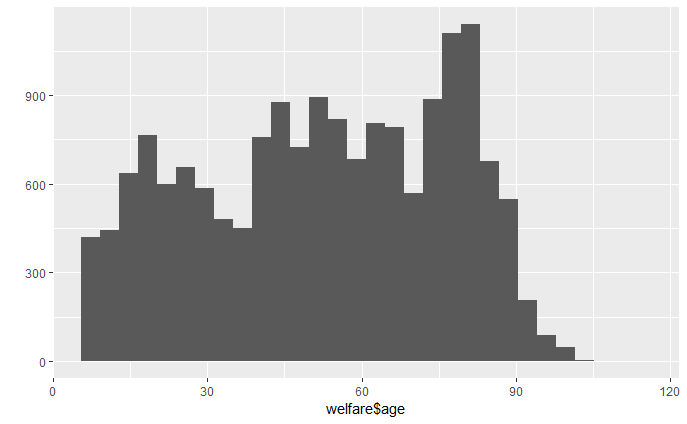

```r
qplot(welfare$age)
```

### 나이와 월급의 관계 분석하기

#### 1. 나이에 따른 월급 평균표 만들기

```r
age_income <- welfare %>%
  filter(!is.na(income)) %>%
  group_by(age) %>%
  summarise(mean_income = mean(income))
head(age_income)
```

| age | mean_income |
| --- | --- |
| 24 | 121.3000 |
| 25 | 105.5185 |
| 26 | 130.0923 |
| 27 | 141.7157 |
| 28 | 134.0877 |
| 29 | 144.6559 |

#### 2. 그래프 만들기

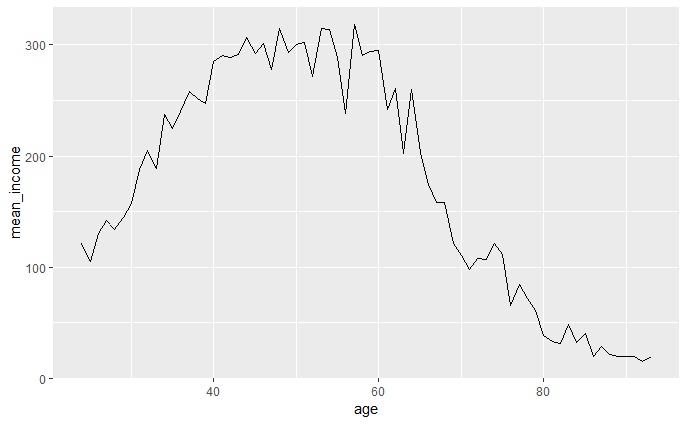

```r
ggplot(data = age_income, aes(x = age, y = mean_income)) + geom_line()
```

## 09-4. 연령대에 따른 월급 차이

## - “어떤 연령대의 월급이 가장 많을까?”

#### 분석 절차

**1. 변수 검토 및 전처리**

- 연령대
- 월급

**2. 변수 간 관계 분석**

- 연령대별 월급 평균표 만들기
- 그래프 만들기

### 연령대 변수 검토 및 전처리하기

#### 파생변수 만들기 - 연령대

```r
welfare <- welfare %>%
  mutate(ageg = ifelse(age < 30, "young",
                       ifelse(age <= 59, "middle", "old")))
table(welfare$ageg)
```

```
middle    old  young
  5702   7126   3836
```

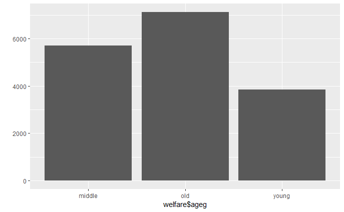

```r
qplot(welfare$ageg)
```

### 연령대에 따른 월급 차이 분석하기

#### 1. 연령대별 월급 평균표 만들기

```r
ageg_income <- welfare %>%
  filter(!is.na(income)) %>%
  group_by(ageg) %>%
  summarise(mean_income = mean(income))
ageg_income
```

| ageg | mean_income |
| --- | --- |
| middle | 276.6914 |
| old | 162.6111 |
| young | 134.2503 |

#### 2. 그래프 만들기

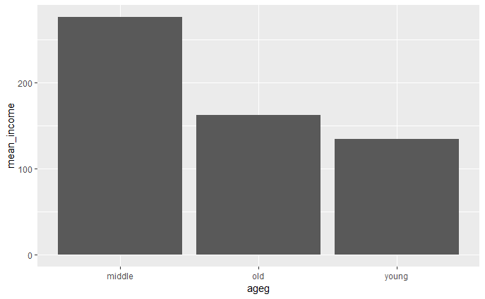

```r
ggplot(data = ageg_income, aes(x = ageg, y = mean_income)) + geom_col()
```

#### 막대 정렬 : 초년, 중년, 노년 나이 순

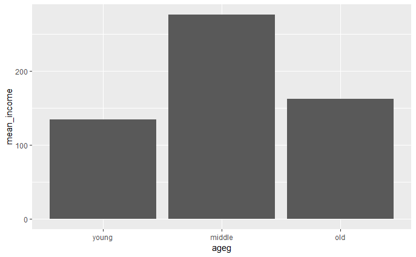

```r
ggplot(data = ageg_income, aes(x = ageg, y = mean_income)) +
  geom_col() +
  scale_x_discrete(limits = c("young", "middle", "old"))
```

## 09-5. 연령대 및 성별 월급 차이

## - “성별 월급 차이는 연령대별로 다를까?”

#### 분석 절차

**1. 변수 검토 및 전처리**

- 연령대
- 성별
- 월급

**2. 변수 간 관계 분석**

- 연령대 및 성별 월급 평균표 만들기
- 그래프 만들기

### 연령대 및 성별 월급 차이 분석하기

#### 1. 연령대 및 성별 월급 평균표 만들기

```r
sex_income <- welfare %>%
  filter(!is.na(income)) %>%
  group_by(ageg, sex) %>%
  summarise(mean_income = mean(income))
sex_income
```

| ageg | sex | mean_income |
| --- | --- | --- |
| middle | female | 192.2116 |
| middle | male | 343.9702 |
| old | female | 96.3227 |
| old | male | 229.6098 |
| young | female | 134.2395 |
| young | male | 134.2748 |

#### 2. 그래프 만들기

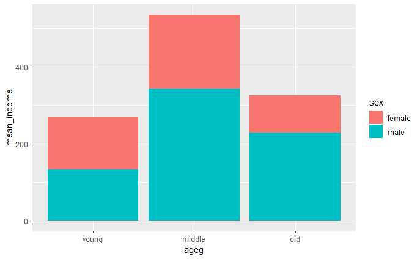

```r
ggplot(data = sex_income, aes(x = ageg, y = mean_income, fill = sex)) +
  geom_col() +
  scale_x_discrete(limits = c("young", "middle", "old"))
```

#### 성별 막대 분리

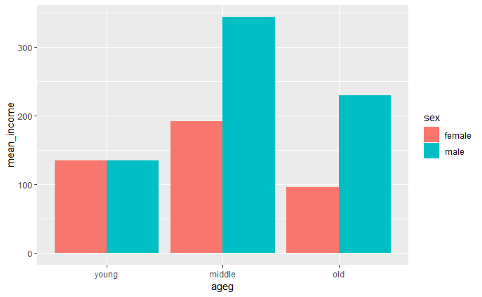

```r
ggplot(data = sex_income, aes(x = ageg, y = mean_income, fill = sex)) +
  geom_col(position = "dodge") +
  scale_x_discrete(limits = c("young", "middle", "old"))
```

### 나이 및 성별 월급 차이 분석하기

```r
# 성별 연령별 월급 평균표 만들기
sex_age <- welfare %>%
  filter(!is.na(income)) %>%
  group_by(age, sex) %>%
  summarise(mean_income = mean(income))
head(sex_age)
```

| age | sex | mean_income |
| --- | --- | --- |
| 24 | female | 147.4500 |
| 24 | male | 69.0000 |
| 25 | female | 106.9789 |
| 25 | male | 102.0500 |
| 26 | female | 139.8547 |
| 26 | male | 118.2379 |

#### 2. 그래프 만들기

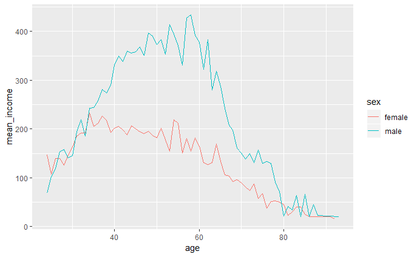

```r
ggplot(data = sex_age, aes(x = age, y = mean_income, col = sex)) + geom_line()
```

## 09-6. 직업별 월급 차이

## - “어떤 직업이 월급을 가장 많이 받을까?”

#### 분석 절차

**1. 변수 검토 및 전처리**

- 직업
- 월급

**2. 변수 간 관계 분석**

- 직업별 월급 평균표 만들기
- 그래프 만들기

#### 1. 변수 검토하기

```r
class(welfare$code_job)
```

```
[1] "numeric"
```

```r
table(welfare$code_job)
```

```
 111  120  131  132  133  134  135  139  141  149  151  152  153  159  211  212
   2   16   10   11    9    3    7   10   35   20   26   18   15   16    8    4
 213  221  222  223  224  231  232  233  234  235  236  237  239  241  242  243
   3   17   31   12    4   41    5    3    6   48   14    2   29   12    4   63
 244  245  246  247  248  251  252  253  254  259  261  271  272  273  274  281
   4   33   59   77   38   14  111   24   67  109    4   15   11    4   36   17
 283  284  285  286  289  311  312  313  314  320  330  391  392  399  411  412
   8   10   26   16    5  140  260  220   84   75   15    4   13   87   47   12
 421  422  423  429  431  432  441  442  510  521  522  530  611  612  613  620
 124   71    5   14   20   33  154  197  192  353    5  106 1320   11   40    2
 630  710  721  722  730  741  742  743  751  752  753  761  762  771  772  773
  20   29   30   22   16   27    3   34   34    5   49   69   27   11   61   86
 774  780  791  792  799  811  812  819  821  822  823  831  832  841  842  843
   7   17    5   21   45   16    1    6    9    9   23    5   17   32   10    4
 851  852  853  854  855  861  862  863  864  871  873  874  875  876  881  882
  19   13    7   33    9    3   14   17   31    2  257   34   37    2    2    3
 891  892  899  910  921  922  930  941  942  951  952  953  991  992  999 1011
   8   19   16  102   31   74  289  325   99  125  122   73   45   12  141    2
1012
  17
```

#### 2. 전처리

**직업분류코드 목록 불러오기**

```r
library(readxl)
list_job <- read_excel("data/Koweps_Codebook.xlsx", col_names = T, sheet = 2)
head(list_job)
```

[output not shown]

```r
dim(list_job)
```

```
[1] 149   2
```

**`welfare`에 직업명 결합**

```r
welfare <- left_join(welfare, list_job, id="code_job")
welfare %>%
  filter(!is.na(code_job)) %>%
  select(code_job, job) %>%
  head(10)
```

[output not shown]

### 직업별 월급 차이 분석하기

#### 1. 직업별 월급 평균표 만들기

```r
job_income <- welfare %>%
  filter(!is.na(job) & !is.na(income)) %>%
  group_by(job) %>%
  summarise(mean_income = mean(income))
head(job_income)
```

[output not shown]

#### 2. 상위 10개 추출

```r
top10 <- job_income %>%
  arrange(desc(mean_income)) %>%
  head(10)
top10
```

[output not shown]

#### 3. 그래프 만들기

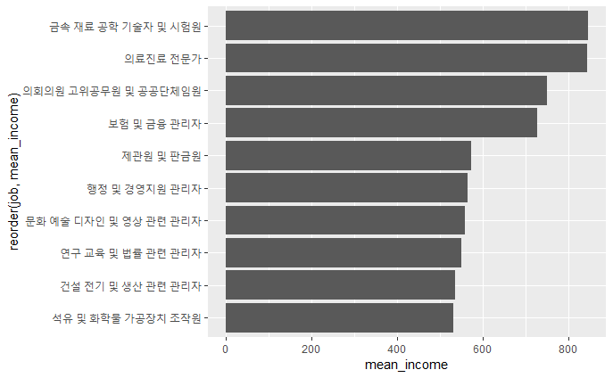

```r
ggplot(data = top10, aes(x = reorder(job, mean_income), y = mean_income)) +
  geom_col() +
  coord_flip()
```

#### 4. 하위 10위 추출

```r
bottom10 <- job_income %>%
  arrange(mean_income) %>%
  head(10)
bottom10
```

[output not shown]

#### 5. 그래프 만들기

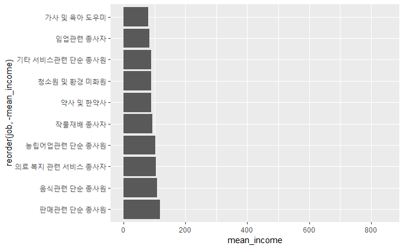

```r
ggplot(data = bottom10, aes(x = reorder(job, -mean_income), y = mean_income)) +
  geom_col() +
  coord_flip() +
  ylim(0, 850)
```

## 09-7. 성별 직업 빈도

## - “성별로 어떤 직업이 가장 많을까?”

#### 분석 절차

**1. 변수 검토 및 전처리**

- 성별
- 직업

**2. 변수 간 관계 분석**

- 성별 직업 빈도표 만들기
- 그래프 만들기

### 성별 직업 빈도 분석하기

#### 1. 성별 직업 빈도표 만들기

```r
# 남성 직업 빈도 상위 10개 추출
job_male <- welfare %>%
  filter(!is.na(job) & sex == "male") %>%
  group_by(job) %>%
  summarise(n = n()) %>%
  arrange(desc(n)) %>%
  head(10)
job_male
```

[output not shown]

```r
# 여성 직업 빈도 상위 10개 추출
job_female <- welfare %>%
  filter(!is.na(job) & sex == "female") %>%
  group_by(job) %>%
  summarise(n = n()) %>%
  arrange(desc(n)) %>%
  head(10)
job_female
```

[output not shown]

#### 2. 그래프 만들기

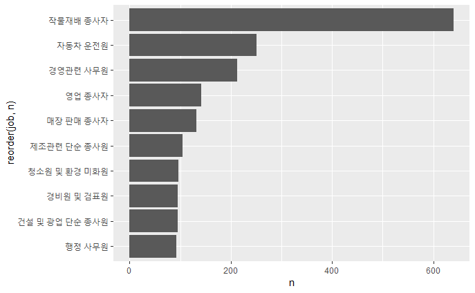

```r
# 남성 직업 빈도 상위 10개 직업
ggplot(data = job_male, aes(x = reorder(job, n), y = n)) +
  geom_col() +
  coord_flip()
```

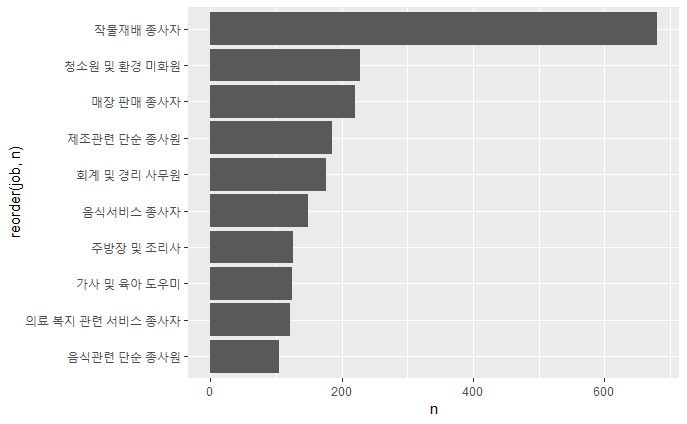

```r
# 여성 직업 빈도 상위 10개 직업
ggplot(data = job_female, aes(x = reorder(job, n), y = n)) +
  geom_col() +
  coord_flip()
```

## 09-8. 종교 유무에 따른 이혼율

## - “종교가 있는 사람들이 이혼을 덜 할까?

#### 분석 절차

**1. 변수 검토 및 전처리**

- 종교
- 혼인 상태

**2. 변수 간 관계 분석**

- 종교 유무에 따른 이혼율 표 만들기
- 그래프 만들기

### 종교 변수 검토 및 전처리하기

#### 1. 변수 검토하기

```r
class(welfare$religion)
```

```
[1] "numeric"
```

```r
table(welfare$religion)
```

```
   1    2
8047 8617
```

#### 2. 전처리

```r
# 종교 유무 이름 부여
welfare$religion <- ifelse(welfare$religion == 1, "yes", "no")
table(welfare$religion)
```

```
  no  yes
8617 8047
```

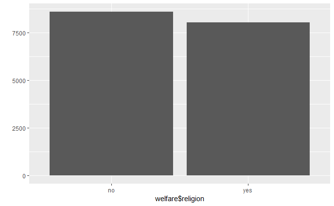

```r
qplot(welfare$religion)
```

### 혼인 상태 변수 검토 및 전처리하기

#### 1. 변수 검토하기

```r
class(welfare$marriage)
table(welfare$marriage)
```

#### 2. 전처리

```r
# 이혼 여부 변수 만들기
welfare$group_marriage <- ifelse(welfare$marriage == 1, "marriage",
                          ifelse(welfare$marriage == 3, "divorce", NA))
table(welfare$group_marriage)
```

```
 divorce marriage
     712     8431
```

```r
table(is.na(welfare$group_marriage))
```

```
FALSE  TRUE
 9143  7521
```

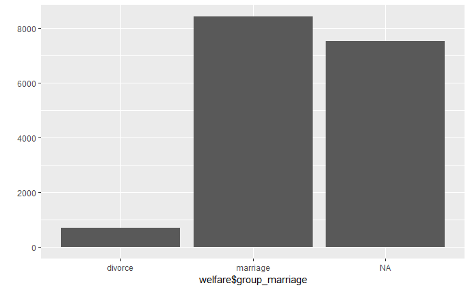

```r
qplot(welfare$group_marriage)
```

### 종교 유무에 따른 이혼율 분석하기

#### 1. 종교 유무에 따른 이혼율 표 만들기

```r
religion_marriage <- welfare %>%
  filter(!is.na(group_marriage)) %>%
  group_by(religion, group_marriage) %>%
  summarise(n = n()) %>%
  mutate(tot_group = sum(n)) %>%
  mutate(pct = round(n/tot_group*100, 1))
religion_marriage
```

| religion | group_marriage | n | tot_group | pct |
| --- | --- | --- | --- | --- |
| no | divorce | 384 | 4602 | 8.3 |
| no | marriage | 4218 | 4602 | 91.7 |
| yes | divorce | 328 | 4541 | 7.2 |
| yes | marriage | 4213 | 4541 | 92.8 |

#### `count()` 활용

```r
religion_marriage <- welfare %>%
  filter(!is.na(group_marriage)) %>%
  count(religion, group_marriage) %>%
  group_by(religion) %>%
  mutate(pct = round(n/sum(n)*100, 1))
```

#### 2. 이혼율 표 만들기

```r
# 이혼 추출
divorce <- religion_marriage %>%
  filter(group_marriage == "divorce") %>%
  select(religion, pct)
divorce
```

| religion | pct |
| --- | --- |
| no | 8.3 |
| yes | 7.2 |

#### 3. 그래프 만들기

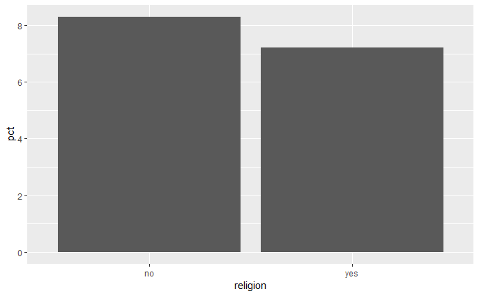

```r
ggplot(data = divorce, aes(x = religion, y = pct)) + geom_col()
```

### 연령대 및 종교 유무에 따른 이혼율 분석하기

#### 1. 연령대별 이혼율 표 만들기

```r
ageg_marriage <- welfare %>%
  filter(!is.na(group_marriage)) %>%
  group_by(ageg, group_marriage) %>%
  summarise(n = n()) %>%
  mutate(tot_group = sum(n)) %>%
  mutate(pct = round(n/tot_group*100, 1))
ageg_marriage
```

| ageg | group_marriage | n | tot_group | pct |
| --- | --- | --- | --- | --- |
| middle | divorce | 346 | 4219 | 8.2 |
| middle | marriage | 3873 | 4219 | 91.8 |
| old | divorce | 365 | 4907 | 7.4 |
| old | marriage | 4542 | 4907 | 92.6 |
| young | divorce | 1 | 17 | 5.9 |
| young | marriage | 16 | 17 | 94.1 |

#### `count()` 활용

```r
ageg_marriage <- welfare %>%
  filter(!is.na(group_marriage)) %>%
  count(ageg, group_marriage) %>%
  group_by(ageg) %>%
  mutate(pct = round(n/sum(n)*100, 1))
```

#### 2. 연령대별 이혼율 그래프 만들기

```r
# 초년 제외, 이혼 추출
ageg_divorce <- ageg_marriage %>%
  filter(ageg != "young" & group_marriage == "divorce") %>%
  select(ageg, pct)
ageg_divorce
```

| ageg | pct |
| --- | --- |
| middle | 8.2 |
| old | 7.4 |

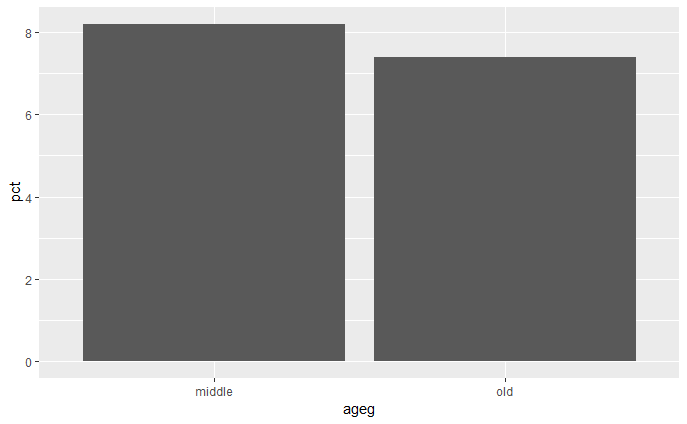

```r
# 그래프 만들기
ggplot(data = ageg_divorce, aes(x = ageg, y = pct)) + geom_col()
```

#### 3. 연령대 및 종교 유무에 따른 이혼율 표 만들기

```r
# 연령대, 종교유무, 결혼상태별 비율표 만들기
ageg_religion_marriage <- welfare %>%
  filter(!is.na(group_marriage) & ageg != "young") %>%
  group_by(ageg, religion, group_marriage) %>%
  summarise(n = n()) %>%
  mutate(tot_group = sum(n)) %>%
  mutate(pct = round(n/tot_group*100, 1))
ageg_religion_marriage
```

| ageg | religion | group_marriage | n | tot_group | pct |
| --- | --- | --- | --- | --- | --- |
| middle | no | divorce | 211 | 2364 | 8.9 |
| middle | no | marriage | 2153 | 2364 | 91.1 |
| middle | yes | divorce | 135 | 1855 | 7.3 |
| middle | yes | marriage | 1720 | 1855 | 92.7 |
| old | no | divorce | 172 | 2229 | 7.7 |
| old | no | marriage | 2057 | 2229 | 92.3 |
| old | yes | divorce | 193 | 2678 | 7.2 |
| old | yes | marriage | 2485 | 2678 | 92.8 |

#### `count()` 활용

```r
ageg_religion_marriage <- welfare %>%
  filter(!is.na(group_marriage) & ageg != "young") %>%
  count(ageg, religion, group_marriage) %>%
  group_by(ageg, religion) %>%
  mutate(pct = round(n/sum(n)*100, 1))
```

#### 연령대 및 종교 유무별 이혼율 표 만들기

```r
df_divorce <- ageg_religion_marriage %>%
  filter(group_marriage == "divorce") %>%
  select(ageg, religion, pct)
df_divorce
```

| ageg | religion | pct |
| --- | --- | --- |
| middle | no | 8.9 |
| middle | yes | 7.3 |
| old | no | 7.7 |
| old | yes | 7.2 |

#### 4. 연령대 및 종교 유무에 따른 이혼율 그래프 만들기

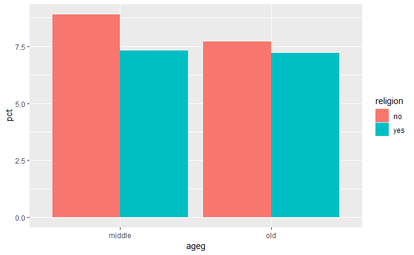

```r
ggplot(data = df_divorce, aes(x = ageg, y = pct, fill = religion )) +
  geom_col(position = "dodge")
```

## 09-9. 지역별 연령대 비율

## - “노년층이 많은 지역은 어디일까?”

#### 분석 절차

**1. 변수 검토 및 전처리**

- 지역
- 연령대

**2. 변수 간 관계 분석**

- 지역별 연령대 비율표 만들기
- 그래프 만들기

### 지역 변수 검토 및 전처리하기

#### 1. 변수 검토하기

```r
class(welfare$code_region)
```

```
[1] "numeric"
```

```r
table(welfare$code_region)
```

```
   1    2    3    4    5    6    7
2486 3711 2785 2036 1467 1257 2922
```

#### 2. 전처리

```r
# 지역 코드 목록 만들기
list_region <- data.frame(code_region = c(1:7),
                          region = c("서울",
                                     "수도권(인천/경기)",
                                     "부산/경남/울산",
                                     "대구/경북",
                                     "대전/충남",
                                     "강원/충북",
                                     "광주/전남/전북/제주도"))
list_region
```

[output not shown]

#### `welfare`에 지역명 변수 추가

```r
welfare <- left_join(welfare, list_region, id = "code_region")
welfare %>%
  select(code_region, region) %>%
  head
```

[output not shown]

### 지역별 연령대 비율 분석하기

#### 1. 지역별 연령대 비율표 만들기

```r
region_ageg <- welfare %>%
  group_by(region, ageg) %>%
  summarise(n = n()) %>%
  mutate(tot_group = sum(n)) %>%
  mutate(pct = round(n/tot_group*100, 2))
head(region_ageg)
```

[output not shown]

#### `count()` 활용

```r
region_ageg <- welfare %>%
  count(region, ageg) %>%
  group_by(region) %>%
  mutate(pct = round(n/sum(n)*100, 2))
```

#### 2. 그래프 만들기

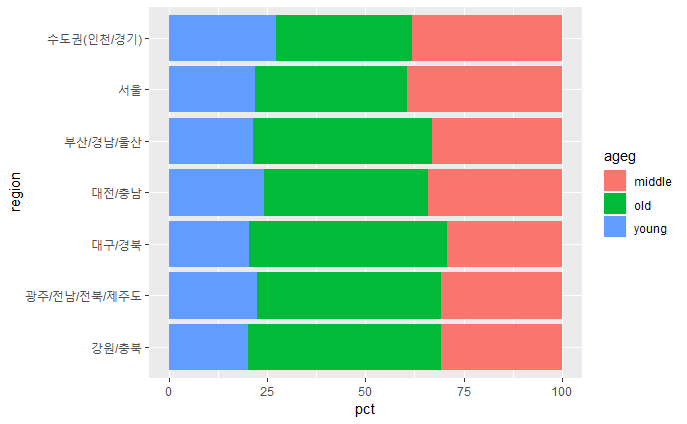

```r
ggplot(data = region_ageg, aes(x = region, y = pct, fill = ageg)) +
  geom_col() +
  coord_flip()
```

#### 3. 막대 정렬하기 : 노년층 비율 높은 순

```r
# 노년층 비율 내림차순 정렬
list_order_old <- region_ageg %>%
  filter(ageg == "old") %>%
  arrange(pct)
list_order_old
```

[output not shown]

```r
# 지역명 순서 변수 만들기
order <- list_order_old$region
order
```

```
[1] 수도권(인천/경기)     서울                  대전/충남
[4] 부산/경남/울산        광주/전남/전북/제주도 강원/충북
[7] 대구/경북
7 Levels: 강원/충북 광주/전남/전북/제주도 대구/경북 대전/충남 ... 수도권(인천/경기)
```

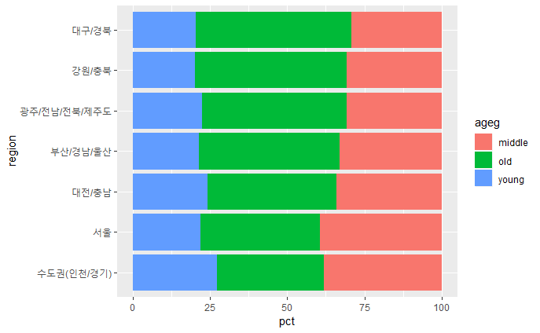

```r
ggplot(data = region_ageg, aes(x = region,  y = pct, fill = ageg)) +
  geom_col() +
  coord_flip() +
  scale_x_discrete(limits = order)
```

#### 4. 연령대 순으로 막대 색깔 나열하기

```r
class(region_ageg$ageg)
```

```
[1] "character"
```

```r
levels(region_ageg$ageg)
```

```r
region_ageg$ageg <- factor(region_ageg$ageg,
                           level = c("old", "middle", "young"))
class(region_ageg$ageg)
```

```
[1] "factor"
```

```r
levels(region_ageg$ageg)
```

```
[1] "old"    "middle" "young"
```

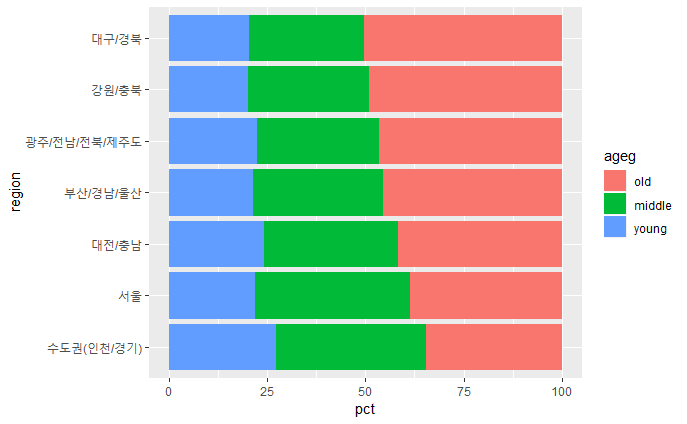

```r
ggplot(data = region_ageg, aes(x = region,  y = pct, fill = ageg)) +
  geom_col() +
  coord_flip() +
  scale_x_discrete(limits = order)
```